# Infrastructure and Citation Analysis

Awan Afiaz - Graduate Student

2023-03-09

## Part I: Data loading and check

```r
## Load data file1: The Software Impact Dataset from John
wdat <- read.table(file='itcr_softwarekg_articles.tsv', sep = '\t', header = TRUE, fill = TRUE) %>%
  rename(toolName = name_from_itcr_simplified) %>%
  mutate(toolName = str_trim(toolName))

## Tool Analysis dataset, modified version with all the edited/recoded variables
tdat <- read_csv(file = "tdat_edited.csv", show_col_types = FALSE)  %>%
  rename(toolName = `tool name`) %>%
  mutate(toolName = str_trim(toolName))
```

```r
health <- read_csv(here::here("Tool_data_health_metrics.csv"))

count(health, health_metrics)
```

```
## # A tibble: 17 × 2
##    health_metrics             n
##    <chr>                  <int>
##  1 ?                          1
##  2 CI and coverage badges     1
##  3 CI but not badge           1
##  4 CI with badge              2
##  5 no                         1
##  6 No                        15
##  7 Not for core software      1
##  8 on bioconductor only       2
##  9 Test badges                1
## 10 travis but no badge        1
## 11 unknown status             1
## 12 unknown status badge       2
## 13 Yes                        2
## 14 yes build                  1
## 15 Yes build                  1
## 16 Yes coverage and build     1
## 17 <NA>                      10
```

```r
health %<>% mutate(simple_health_metrics = case_when(
  str_detect(health_metrics,
"no|No|unknown status|no badge|Not for core software|CI but not badge|\\?") ~ "No",
 str_detect(health_metrics,
"Yes|yes|Test badges|CI and coverage badges|bioconductor only| with badge")~ "Yes",
  TRUE ~ health_metrics
))

identical(tdat$toolName, health$`tool name`)
```

```
## [1] TRUE
```

```r
tdat$simple_health_metrics <- health$simple_health_metrics
```

## 1. Proportion of softwares with health metrics shown

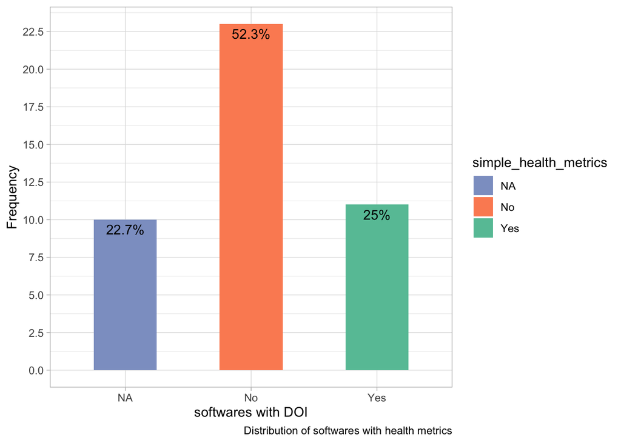

```r
tdat %>%
    mutate(simple_health_metrics = case_when(is.na(simple_health_metrics)~ "NA", TRUE ~simple_health_metrics))%>%
  ggplot(aes(x = simple_health_metrics, fill = simple_health_metrics)) +
  geom_bar( width = 0.5) +
  geom_text(stat = 'count', aes(label = paste0(after_stat(round(100*count/sum(count),1)), "%")), vjust = 1.5) +
  labs(x = "softwares with DOI", y = "Frequency", caption = "Distribution of softwares with health metrics") +
  scale_y_continuous(n.breaks = 10) +
  scale_fill_brewer(palette = "Set2", direction = -1) +
  theme_light()
```

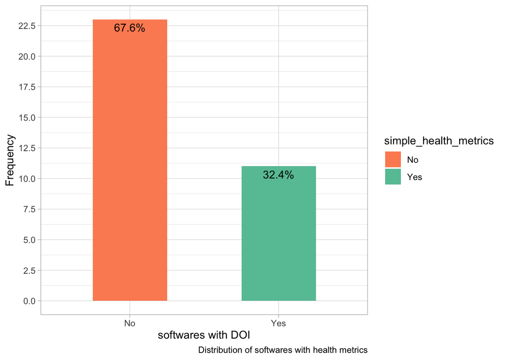

```r
tdat %>%
    drop_na(simple_health_metrics) %>%
  ggplot(aes(x = simple_health_metrics, fill = simple_health_metrics)) +
  geom_bar( width = 0.5) +
  geom_text(stat = 'count', aes(label = paste0(after_stat(round(100*count/sum(count),1)), "%")), vjust = 1.5) +
  labs(x = "softwares with DOI", y = "Frequency", caption = "Distribution of softwares with health metrics") +
  scale_y_continuous(n.breaks = 10) +
  scale_fill_brewer(palette = "Set2", direction = -1) +
  theme_light()
```

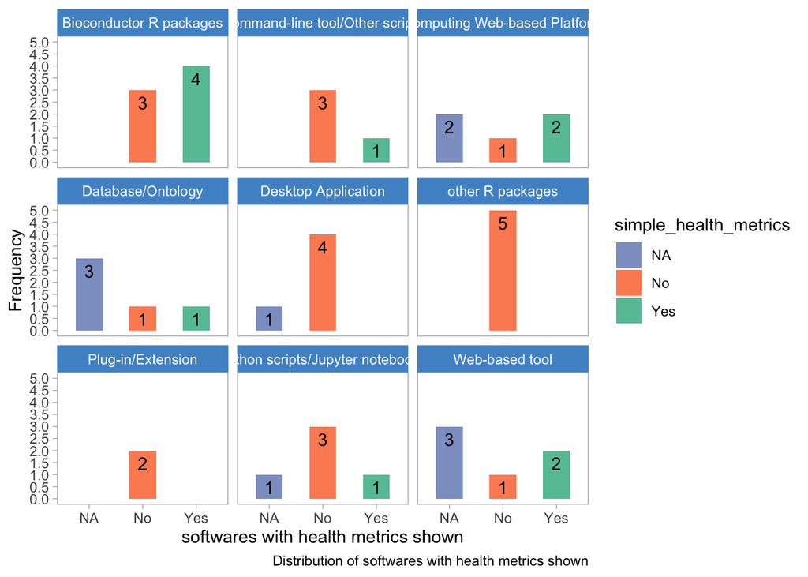

```r
tdat %>%
  mutate(simple_health_metrics = case_when(is.na(simple_health_metrics)~ "NA", TRUE ~simple_health_metrics))%>%
  ggplot(aes(x = simple_health_metrics, fill = simple_health_metrics)) +
  geom_bar( width = 0.5) +
  geom_text(stat = 'count', aes(label = after_stat(count), vjust = 1.5)) +
  facet_wrap(~`class/type`) +
  labs(x = "softwares with health metrics shown", y = "Frequency", caption = "Distribution of softwares with health metrics shown") +
  scale_y_continuous(n.breaks = 10) +
  scale_fill_brewer(palette = "Set2", direction = -1) +
  theme_light() +
  theme(strip.background =element_rect(fill="steelblue3"),
        strip.text = element_text(colour = 'white'),
        panel.grid = element_blank())
```

## Caveats with the data set

- The definitions of each column type are as follows:
  - **‘name_in_reference’** is the specific spelling/capitalization used in the pubmed article
  - **‘name_from_itcr_simplified’** is the input key provided to the database (case insensitive word matching)
  - **“usage”** is usage, **“allusion”** is a simple mention, like ‘software xyz exists’,
  - **“deposition”** and **“creation”** indicate statements about the development or release of the software, like ‘we put xyz on github’
- The software that generated the data considered the names as case-sensitive. So, for example, “Galaxy”, “GALAXY” were considered distinct.
- Look at the following table for a specific article (ID: PMC4765054),
  - **name_in_reference** (column 3) shows that issue mentioned above.
  - However, **toolName** (column 7) is same for all 6 rows
- Therefore, to generate the frequency table for **how many articles** cited a specific software, we need only keep the rows that are distinct in toolName and article (PMC IDs).

```r
wdat %>% filter(article == "PMC4765054") %>% arrange(name_in_reference) %>% select(-software) %>%
  DT::datatable(caption = htmltools::tags$caption("Case sensitivity and redundant rows", style = "color:red"))
```

|  | article | mentionType | name_in_reference | year | num_abs_mention | toolName |
| --- | --- | --- | --- | --- | --- | --- |
| 1 | PMC4765054 | Usage | Galaxy | 2016 | 2 | Galaxy |
| 2 | PMC4765054 | Creation | Galaxy | 2016 | 4 | Galaxy |
| 3 | PMC4765054 | Allusion | Galaxy | 2016 | 20 | Galaxy |
| 4 | PMC4765054 | Allusion | GALAXY | 2016 | 1 | Galaxy |
| 5 | PMC4765054 | Creation | GALAXY | 2016 | 1 | Galaxy |
| 6 | PMC4765054 | Deposition | GALAXY | 2016 | 1 | Galaxy |

- Keep in mind that, each article can mention two or more tools.

```r
wdat %>% filter(article == "PMC4606501") %>% arrange(name_in_reference) %>% select(-software) %>%
  DT::datatable(caption = htmltools::tags$caption("Example of one article mentioning multiple tools", style = "color:red"))
```

|  | article | mentionType | name_in_reference | year | num_abs_mention | toolName |
| --- | --- | --- | --- | --- | --- | --- |
| 1 | PMC4606501 | Creation | Cytoscape | 2015 | 4 | Cytoscape |
| 2 | PMC4606501 | Allusion | Cytoscape | 2015 | 8 | Cytoscape |
| 3 | PMC4606501 | Usage | Cytoscape | 2015 | 15 | Cytoscape |
| 4 | PMC4606501 | Usage | Pathway Commons | 2015 | 2 | Pathway Commons |
| 5 | PMC4606501 | Allusion | Pathway Commons | 2015 | 3 | Pathway Commons |
| 6 | PMC4606501 | Allusion | viPEr | 2015 | 7 | VIPER |
| 7 | PMC4606501 | Deposition | viPEr | 2015 | 4 | VIPER |
| 8 | PMC4606501 | Usage | viPEr | 2015 | 12 | VIPER |
| 9 | PMC4606501 | Creation | viPEr | 2015 | 5 | VIPER |

```r
## As a measure of check,
# ## Re-create the first table sent by John (case-sensitive rows merged)
# wdat %>%
#   group_by(toolName) %>%
#   count(mentionType, wt = num_abs_mention) %>%
#   ungroup() %>%
#   pivot_wider(names_from = mentionType, values_from = n)
# # %>% summarize(across(.cols = where(is.numeric), .fns = sum, na.rm = TRUE) ) %>% sum

# unique(wdat %>% select(article, toolName))
```

- There are **60970 unique articles** in the data set.

## Frequency distribution of article mentions for each tool

```r
## Overall frequency table (allusion or creation or deposition or usage)
freq_tab <- wdat %>% group_by(toolName) %>% count(article) %>% ungroup() %>%
  count(toolName)

freq_tab %>% arrange(desc(n)) %>% rename(`Total article mentions` = n) %>%
  DT::datatable(caption = htmltools::tags$caption("Overall frequency table (allusion or creation or deposition or usage)",
                                                  style = "color:blue"),
                options = list(columnDefs = list(list(className = 'dt-center', targets="_all"))))
```

|  | toolName | Total article mentions |
| --- | --- | --- |
| 1 | Bioconductor | 19589 |
| 2 | Cytoscape | 18528 |
| 3 | QIIME | 9665 |
| 4 | Trinity | 5958 |
| 5 | GSEA | 4090 |
| 6 | Galaxy | 3677 |
| 7 | cBioPortal | 2685 |
| 8 | 3D Slicer | 1201 |
| 9 | MSigDB | 992 |
| 10 | Xena | 669 |

[output cut: 26 more lines]

## Frequency of different mode of mentions

- Note that the last four columns (Allusion, Creation, Deposition, Usage) **Need Not sum** to the total article mentions as one or more of these different type of mentions may have occurred for a speicific tool in each article.

```r
freq_tab_full <- wdat %>%
  group_by(toolName) %>% count(article, mentionType) %>% ungroup() %>%
  group_by(mentionType) %>% count(toolName) %>% ungroup() %>% arrange(toolName) %>%
  pivot_wider(names_from = mentionType, values_from = n) %>%
  right_join(freq_tab, by = "toolName") %>% relocate(n, .after = toolName) %>%
  arrange(desc(n)) %>% rename(`Total article mentions` = n)

 freq_tab_full %>%
  # %>% rowwise() %>% mutate(total = sum(Allusion+Creation+Deposition+Usage, na.rm = T))
  DT::datatable(caption = htmltools::tags$caption("Frequency of different mode of mentions", style = "color:blue"),
                options = list(columnDefs = list(list(className = 'dt-center', targets = "_all"))))
```

|  | toolName | Total article mentions | Allusion | Creation | Deposition | Usage |
| --- | --- | --- | --- | --- | --- | --- |
| 1 | Bioconductor | 19589 | 2654 | 65 | 20 | 17915 |
| 2 | Cytoscape | 18528 | 1516 | 80 | 51 | 18008 |
| 3 | QIIME | 9665 | 539 | 30 | 15 | 9408 |
| 4 | Trinity | 5958 | 478 | 13 | 4 | 5853 |
| 5 | GSEA | 4090 | 89 | 17 | 31 | 3994 |
| 6 | Galaxy | 3677 | 1059 | 119 | 85 | 2920 |
| 7 | cBioPortal | 2685 | 414 | 13 | 83 | 2440 |
| 8 | 3D Slicer | 1201 | 208 | 33 | 20 | 1061 |
| 9 | MSigDB | 992 | 95 | 2 | 4 | 910 |
| 10 | Xena | 669 | 27 | 2 | 14 | 649 |

[output cut: 26 more lines]

```r
freq_tab_full_redefined <- wdat %>%
  ## We filter out the Creations
  filter(mentionType != "Creation") %>%
  group_by(toolName) %>% count(article, mentionType) %>% ungroup() %>%
  group_by(mentionType) %>% count(toolName) %>% ungroup() %>% arrange(toolName) %>%
  pivot_wider(names_from = mentionType, values_from = n) %>%
  right_join(freq_tab, by = "toolName") %>% relocate(n, .after = toolName) %>%
  arrange(desc(n)) %>% rename(`Total article mentions` = n)

## Use ^this freq_tab_full_redefined for the data merger
```

```r
## Join ToolAnalysis data with SoftMention data
## We consider QIIME 2 as QIIME for simplicity
## mwdat = merged working data
tdat_edited <- tdat %>%
  mutate(## Extract all the acronyms inside the parentheses
         names_cut = str_extract_all(toolName, "\\([^()]+\\)") %>% substring(., 2, nchar(.)-1),
         ## remove the nonsensical names_cut for names that did not contain acronyms inside the parentheses
         names_cut = if_else(names_cut == "haracter(0", toolName, names_cut),
         ## Keep only the first word in each name (since this is most common in the Software data)
         names_cut = word(names_cut, 1),
         ## Individually fix those who had standalone issues or problems with operations above
         names_cut = case_when(names_cut == "AA" ~ "AmpliconArchitect",
                               names_cut == "AR" ~ "AmpliconReconstructor",
                               names_cut == "dcmqi:" ~ "dcmqi",
                               names_cut == "PDX" ~ "PDXFinder",
                               names_cut == "3D" ~ "3D Slicer",
                               names_cut == "Pathway" ~ "Pathway Commons",
                               names_cut == "UCSC" ~ "Xena",
                               TRUE ~ names_cut),
         ## remove any whitespaces before after names
         names_cut = str_trim(names_cut)) %>%
  ## remove the original tool name variable and replace with newly generated names for merging
  select(-toolName) %>% rename(toolName = names_cut) %>% relocate(toolName)

## merge with the smaller data set on the right (Update: Use the counts without creation)
mwdat <- tdat_edited %>%
  right_join(freq_tab_full_redefined %>% rename(totalMentions = `Total article mentions`), by = "toolName")

## Some helpful recoding
mwdat %<>% mutate(citeHow = if_else(citeHow == "Yes", citeHow, "No"),
                 TimeSinceLastUpdate_bin = if_else(TimeSinceLastUpdate < 2, "<= 1 year", "2+ years"),
                 ## combine not working with limited: extensiveContact
                 extensiveContact = if_else(extensiveContact == "NotWorking", "None", extensiveContact)
                 )

#mwdat %>% count(extensiveContact)
```

## Analyses

### 1. Possible association between social media presence and log(totalMentions)

- Note that we are using log-scaled data since the data is count-type and there is considerable variation in it.

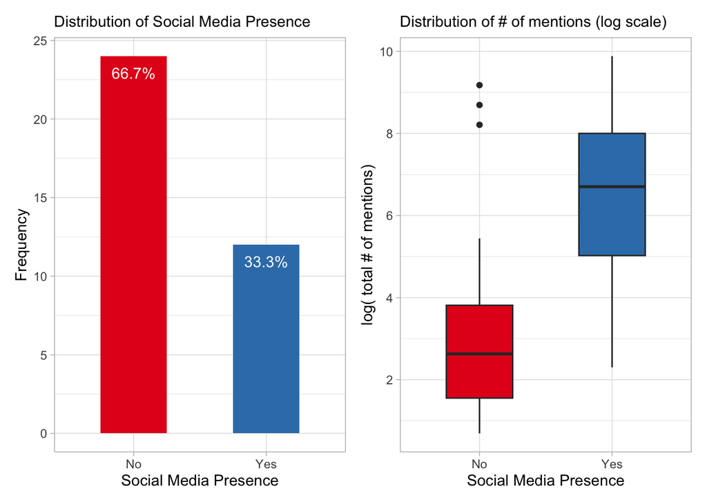

```r
## Marginal dist
p1 <- mwdat %>%
  ggplot(aes(x = socialMedia, fill = fct_infreq(socialMedia))) +
  geom_bar(position = "dodge", width = .5, show.legend = F) +
  geom_text(stat = 'count',
            aes(label = paste0(after_stat(round(100*count/sum(count),1)), "%")),
            position = position_dodge(width = .9), vjust = 2, col = "white") +
  labs(x = "Social Media Presence", y = "Frequency", subtitle = "Distribution of Social Media Presence") +
  scale_y_continuous(n.breaks = 7) +
  scale_fill_brewer(palette = "Set1", direction = 1) +
  theme_light()

p2 <- mwdat %>%
  ggplot(aes(x = socialMedia, y = log(totalMentions))) +
  geom_boxplot(aes(fill = socialMedia),  width = 0.5, show.legend = F) +
  scale_y_continuous(n.breaks = 6) +
  scale_fill_brewer(palette = "Set1", direction = 1) +
  labs(x = "Social Media Presence", y = "log( total # of mentions)",
       subtitle = "Distribution of # of mentions (log scale)") +
  theme_light()

p1 + p2
```

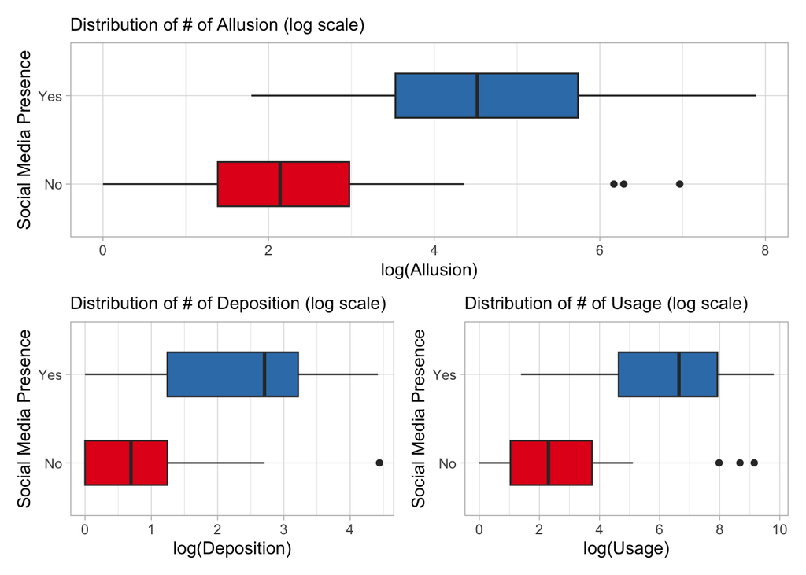

```r
## Allusions
p21 <- mwdat %>% filter(!is.na(Allusion)) %>%
  ggplot(aes(x = socialMedia, y = log(Allusion))) +
  geom_boxplot(aes(fill = socialMedia),  width = 0.5, show.legend = F) +
  scale_y_continuous(n.breaks = 6) +
  scale_fill_brewer(palette = "Set1", direction = 1) +
  labs(x = "Social Media Presence", y = "log(Allusion)", subtitle = "Distribution of # of Allusion (log scale)") +
  theme_light() + coord_flip()

## Deposition
p23 <- mwdat %>% filter(!is.na(Deposition)) %>%
  ggplot(aes(x = socialMedia, y = log(Deposition))) +
  geom_boxplot(aes(fill = socialMedia),  width = 0.5, show.legend = F) +
  scale_y_continuous(n.breaks = 6) +
  scale_fill_brewer(palette = "Set1", direction = 1) +
  labs(x = "Social Media Presence", y = "log(Deposition)",
       subtitle = "Distribution of # of Deposition (log scale)") +
  theme_light() + coord_flip()

## Usage
p24 <- mwdat %>% filter(!is.na(Usage)) %>%
  ggplot(aes(x = socialMedia, y = log(Usage))) +
  geom_boxplot(aes(fill = socialMedia),  width = 0.5, show.legend = F) +
  scale_y_continuous(n.breaks = 6) +
  scale_fill_brewer(palette = "Set1", direction = 1) +
  labs(x = "Social Media Presence", y = "log(Usage)", subtitle = "Distribution of # of Usage (log scale)") +
  theme_light() + coord_flip()

(p21) / (p23 + p24)
```

- It appears the distribution of log-frequency (and hence the frequency) differs significantly.
- However, mention is a function of time as well. So we need to check whether adjusting age of tool affects this crude association.

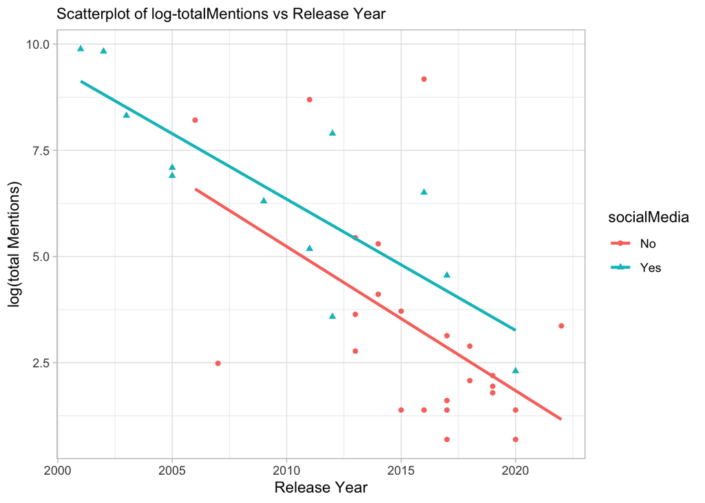

```r
## I found out the release years for the tools: Cytoscape (2002), RDriver (2017)
regdat <- mwdat %>%
  mutate(releaseYear = case_when(toolName == "rDriver" ~ 2017,
                                 toolName == "Cytoscape" ~ 2002,
                                 TRUE ~ releaseYear),
         ## Year 2022 is completed, hence those created in 2022 could be considered as Year 1 age
         toolAge = 2023 - releaseYear,
         ## Since this is only the beginning of 2023, we count up to the year 2022
         TimeSinceLastUpdate = 2022 - updateYear)

p3 <- regdat %>%
  ggplot(aes(x = releaseYear, y = log(totalMentions), col = socialMedia)) +
  geom_point(aes(shape = socialMedia)) +
  geom_smooth(method = "lm", se = F) +
  labs(x = "Release Year", y = "log(total Mentions)", subtitle = "Scatterplot of log-totalMentions vs Release Year") +
  theme_light()

p3
```

### An exploratory regression

```r
lm(log(totalMentions) ~ socialMedia, data = regdat) %>% broom::tidy() %>%
  mutate(across(.cols = where(is.numeric), .fns = ~round(.x, digits = 4))) %>%
  DT::datatable()
```

|  | term | estimate | std.error | statistic | p.value |
| --- | --- | --- | --- | --- | --- |
| 1 | (Intercept) | 3.312 | 0.4904 | 6.7537 | 0 |
| 2 | socialMediaYes | 3.2166 | 0.8494 | 3.7869 | 0.0006 |

```r
lm(log(totalMentions) ~ socialMedia + toolAge, data = regdat) %>% broom::tidy() %>%
  mutate(across(.cols = where(is.numeric), .fns = ~round(.x, digits = 5))) %>%
  DT::datatable()
```

|  | term | estimate | std.error | statistic | p.value |
| --- | --- | --- | --- | --- | --- |
| 1 | (Intercept) | 0.94891 | 0.62034 | 1.52966 | 0.13563 |
| 2 | socialMediaYes | 1.20258 | 0.78083 | 1.54013 | 0.13306 |
| 3 | toolAge | 0.32224 | 0.06675 | 4.82758 | 3e-05 |

- Adjusting for Tool age (a translation of release Year) shows that social media presence is not significant.
- The variability is too high to conclude anything statistically.

## Stratification by: How to cite instruction (with BioConductor)

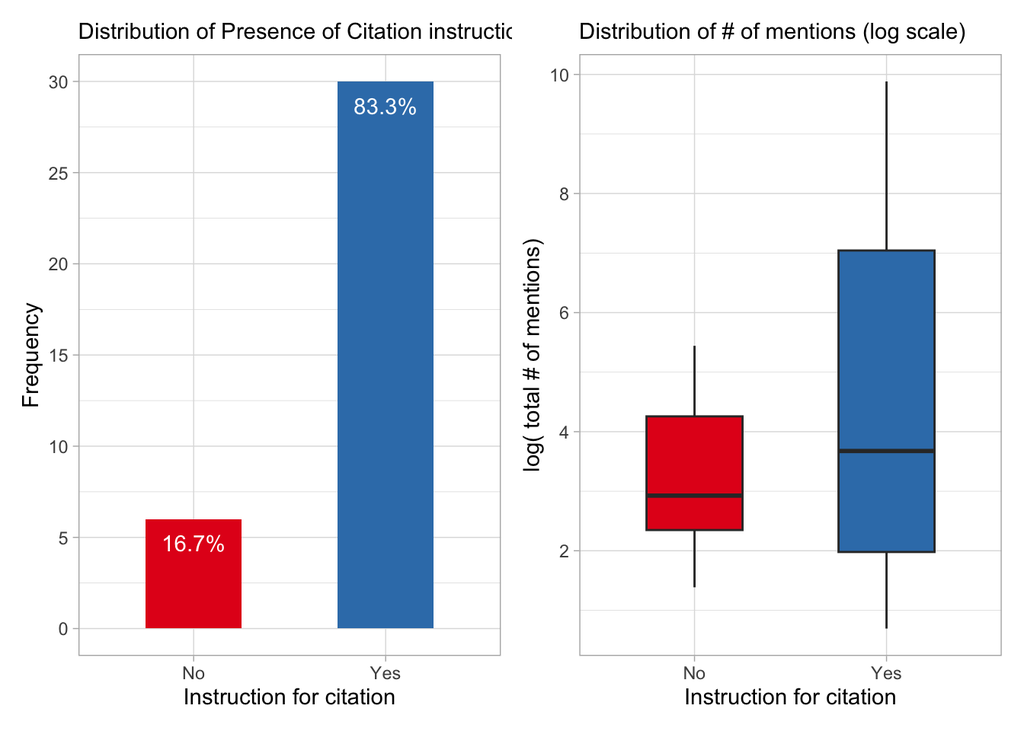

```r
## Marginal dist
p4 <- mwdat %>%
  ggplot(aes(x = citeHow, fill = fct_infreq(citeHow))) +
  geom_bar(position = "dodge", width = .5, show.legend = F) +
  geom_text(stat = 'count',
            aes(label = paste0(after_stat(round(100*count/sum(count),1)), "%")),
            position = position_dodge(width = .9), vjust = 2, col = "white") +
  labs(x = "Instruction for citation", y = "Frequency", subtitle = "Distribution of Presence of Citation instructions") +
  scale_y_continuous(n.breaks = 7) +
  scale_fill_brewer(palette = "Set1", direction = -1) +
  theme_light()

p5 <- mwdat %>%
  ggplot(aes(x = citeHow, y = log(totalMentions))) +
  geom_boxplot(aes(fill = citeHow),  width = 0.5, show.legend = F) +
  scale_y_continuous(n.breaks = 6) +
  scale_fill_brewer(palette = "Set1", direction = 1) +
  labs(x = "Instruction for citation", y = "log( total # of mentions)",
       subtitle = "Distribution of # of mentions (log scale)") +
  theme_light()

p4 + p5
```

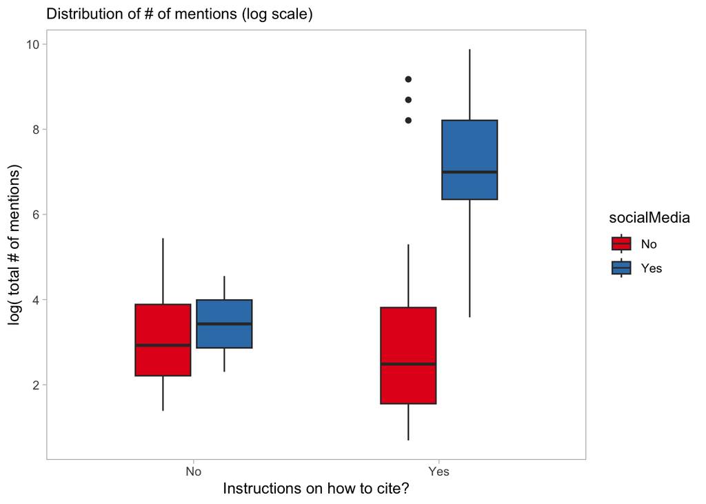

```r
regdat %>%
  ggplot(aes(x = citeHow, y = log(totalMentions))) +
  geom_boxplot(aes(fill = socialMedia),  width = 0.5, ) +
  scale_y_continuous(n.breaks = 6) +
  #facet_wrap(~`class/type`) +
  scale_fill_brewer(palette = "Set1", direction = 1) +
  labs(x = "Instructions on how to cite?", y = "log( total # of mentions)",
       subtitle = "Distribution of # of mentions (log scale)") +
  theme_light() +
  theme(strip.background =element_rect(fill="steelblue3"),
        strip.text = element_text(colour = 'white'),
        panel.grid = element_blank())
```

```r
lm(log(totalMentions) ~ socialMedia + citeHow + socialMedia:citeHow, data = regdat) %>% broom::tidy() %>%
  mutate(across(.cols = where(is.numeric), .fns = ~round(.x, digits = 5))) %>%
  DT::datatable()
```

|  | term | estimate | std.error | statistic | p.value |
| --- | --- | --- | --- | --- | --- |
| 1 | (Intercept) | 3.17023 | 1.16282 | 2.72634 | 0.0103 |
| 2 | socialMediaYes | 0.258 | 2.01406 | 0.1281 | 0.89887 |
| 3 | citeHowYes | 0.17009 | 1.2738 | 0.13353 | 0.89461 |
| 4 | socialMediaYes:citeHowYes | 3.55026 | 2.20629 | 1.60916 | 0.1174 |

- Note: It seems that Tool age is a very strong predictor of the log(mentions), and makes the other variables insignificant.

## (coming) Stratification by: How to cite instruction (WITHOUT BioConductor and other-R packages)

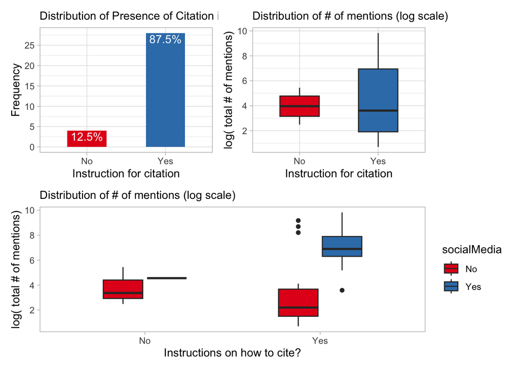

```r
## Marginal dist
p41 <- mwdat %>% filter(`class/type` != c("Bioconductor R packages", "other R packages")) %>%
  ggplot(aes(x = citeHow, fill = fct_infreq(citeHow))) +
  geom_bar(position = "dodge", width = .5, show.legend = F) +
  geom_text(stat = 'count',
            aes(label = paste0(after_stat(round(100*count/sum(count),1)), "%")),
            position = position_dodge(width = .9), vjust = 1.2, col = "white") +
  labs(x = "Instruction for citation", y = "Frequency", subtitle = "Distribution of Presence of Citation instructions") +
  scale_y_continuous(n.breaks = 7) +
  scale_fill_brewer(palette = "Set1", direction = -1) +
  theme_light()

p51 <- mwdat %>% filter(`class/type` != c("Bioconductor R packages", "other R packages")) %>%
  ggplot(aes(x = citeHow, y = log(totalMentions))) +
  geom_boxplot(aes(fill = citeHow),  width = 0.5, show.legend = F) +
  scale_y_continuous(n.breaks = 6) +
  scale_fill_brewer(palette = "Set1", direction = 1) +
  labs(x = "Instruction for citation", y = "log( total # of mentions)",
       subtitle = "Distribution of # of mentions (log scale)") +
  theme_light()


p61 <- regdat %>% filter(`class/type` != c("Bioconductor R packages", "other R packages")) %>%
  ggplot(aes(x = citeHow, y = log(totalMentions))) +
  geom_boxplot(aes(fill = socialMedia),  width = 0.5, ) +
  scale_y_continuous(n.breaks = 6) +
  #facet_wrap(~`class/type`) +
  scale_fill_brewer(palette = "Set1", direction = 1) +
  labs(x = "Instructions on how to cite?", y = "log( total # of mentions)",
       subtitle = "Distribution of # of mentions (log scale)") +
  theme_light() +
  theme(strip.background =element_rect(fill="steelblue3"),
        strip.text = element_text(colour = 'white'),
        panel.grid = element_blank())

(p41 + p51) /
  p61
```

## Stratification by: extensiveContact

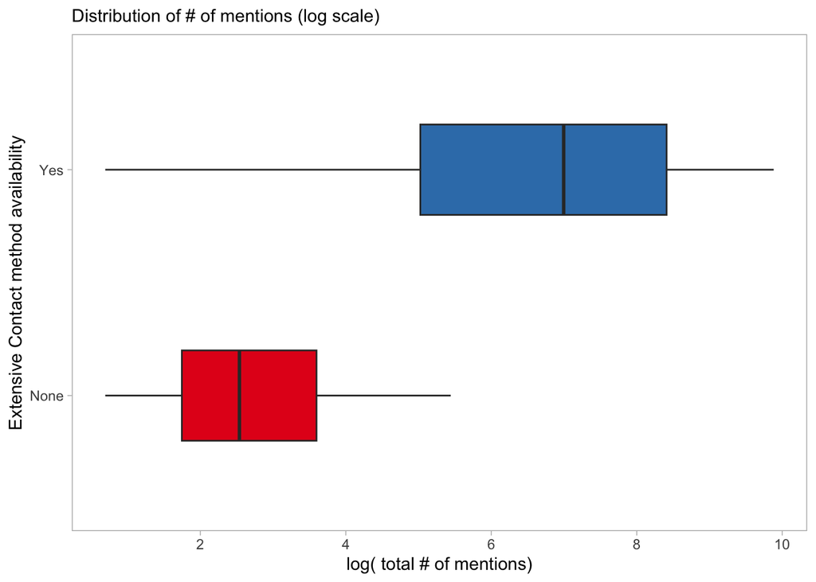

```r
regdat %>% mutate(extensiveContact = if_else(extensiveContact == "None", extensiveContact, "Yes")) %>%
  ggplot(aes(x = extensiveContact, y = log(totalMentions))) +
  geom_boxplot(aes(fill = extensiveContact), width = 0.4, show.legend = F) +
  scale_y_continuous(n.breaks = 6) +
  #facet_wrap(~`class/type`) +
  scale_fill_brewer(palette = "Set1", direction = 1) +
  labs(x = "Extensive Contact method availability", y = "log( total # of mentions)",
       subtitle = "Distribution of # of mentions (log scale)") +
  theme_light() +
  theme(strip.background =element_rect(fill="steelblue3"),
        strip.text = element_text(colour = 'white'),
        panel.grid = element_blank()) + coord_flip()
```

```r
regdat %>% mutate(extensiveContact = if_else(extensiveContact == "None", extensiveContact, "Yes")) %>%
lm(log(totalMentions) ~ extensiveContact + toolAge, data = .) %>% broom::tidy() %>%
  mutate(across(.cols = where(is.numeric), .fns = ~round(.x, digits = 5))) %>%
  DT::datatable()
```

|  | term | estimate | std.error | statistic | p.value |
| --- | --- | --- | --- | --- | --- |
| 1 | (Intercept) | 0.95543 | 0.58634 | 1.62948 | 0.11272 |
| 2 | extensiveContactYes | 1.86396 | 0.74379 | 2.50604 | 0.01732 |
| 3 | toolAge | 0.27614 | 0.06702 | 4.12014 | 0.00024 |

- Having Extensive contact method available is significant EVEN AFTER Ajdusting for Tool age.

## (NEW) Additional Plot: Diversity of the type of tools

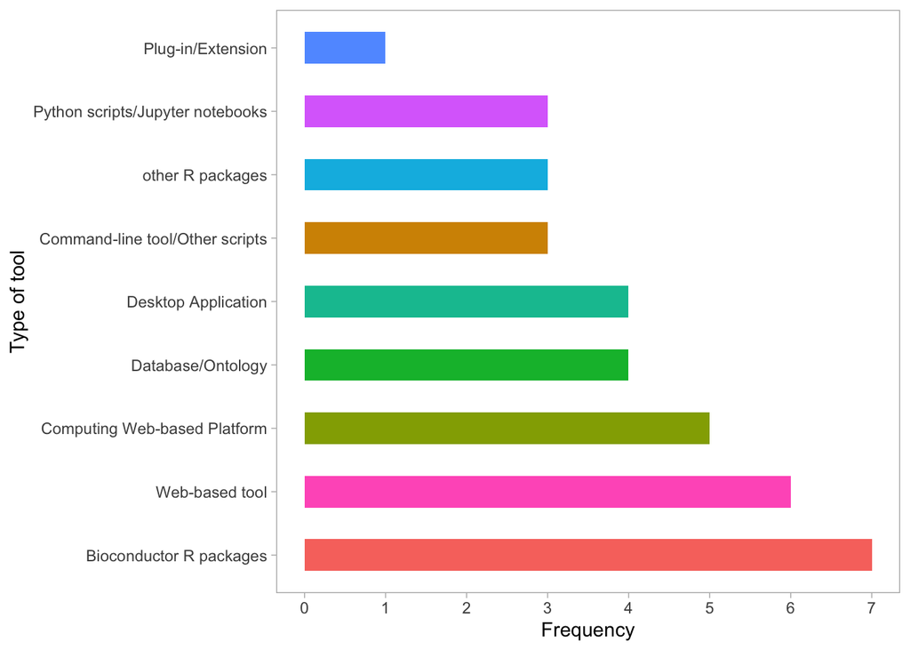

```r
regdat %>% select(toolName, toolType = `class/type`) %>%
  ggplot(aes(y = fct_infreq(toolType), fill = toolType)) +
  geom_bar(width = .5, show.legend = FALSE) +
  labs(x = "Frequency", y = "Type of tool") +
  scale_x_continuous(n.breaks = 7) +
  #scale_fill_brewer(palette = "Set3", direction = 1) +
  theme_light() +
  theme(panel.grid = element_blank() )
```

## (coming) Overlap of tools between survey data and Tool Analysis

```r
tdat_edited %>% mutate(ToolAn_Data = toolName) %>% select(toolName, ToolAn_Data) %>%
  left_join(freq_tab_full_redefined %>% mutate(SImpact_Data = toolName), by = "toolName") %>%
  relocate(ToolAn_Data, SImpact_Data) %>% select(-toolName) %>%
  arrange(SImpact_Data) %>%
  filter(!is.na(SImpact_Data)) %>%
  DT::datatable(caption = "These tools had information in the Software Impact Analysis dataset")
```

|  | ToolAn_Data | SImpact_Data | Total article mentions | Allusion | Deposition | Usage |
| --- | --- | --- | --- | --- | --- | --- |
| 1 | 3D Slicer | 3D Slicer | 1201 | 208 | 20 | 1061 |
| 2 | AMARETTO | AMARETTO | 7 | 5 | 1 | 4 |
| 3 | AmpliconArchitect | AmpliconArchitect | 9 | 5 | 3 | 7 |
| 4 | AmpliconReconstructor | AmpliconReconstructor | 2 | 1 |  | 1 |
| 5 | Bioconductor | Bioconductor | 19589 | 2654 | 20 | 17915 |
| 6 | cBioPortal | cBioPortal | 2685 | 414 | 83 | 2440 |
| 7 | CORE | CORE | 231 | 60 | 3 | 166 |
| 8 | CRAVAT | CRAVAT | 36 | 7 | 2 | 29 |
| 9 | Cytoscape | Cytoscape | 18528 | 1516 | 51 | 18008 |
| 10 | D2Refine | D2Refine | 4 | 3 | 1 | 2 |

[output cut: 26 more lines]

```r
tdat_edited %>% mutate(ToolAn_Data = toolName) %>% select(toolName, ToolAn_Data) %>%
  left_join(freq_tab_full_redefined %>% mutate(SImpact_Data = toolName), by = "toolName") %>%
  relocate(ToolAn_Data, SImpact_Data) %>% select(-toolName) %>%
  arrange(SImpact_Data) %>%
  filter(is.na(SImpact_Data)) %>%
  mutate(ToolAn_Data = case_when(ToolAn_Data == "Gene" ~ "Gene Pattern Notebook",
                                 TRUE ~ ToolAn_Data)) %>%
  DT::datatable(caption = "These tools had no information in the Software Impact Analysis dataset")
```

|  | ToolAn_Data | SImpact_Data | Total article mentions | Allusion | Deposition | Usage |
| --- | --- | --- | --- | --- | --- | --- |
| 1 | MethCon5 |  |  |  |  |  |
| 2 | PRECISION.seq |  |  |  |  |  |
| 3 | Gene Pattern Notebook |  |  |  |  |  |
| 4 | IGV-notebook |  |  |  |  |  |
| 5 | PIIP |  |  |  |  |  |
| 6 | Personalized |  |  |  |  |  |
| 7 | owl-qa |  |  |  |  |  |
| 8 | PETCT_Slicer_Extension |  |  |  |  |  |

## Documentation Depth (manual data)

- The information on all the tools regarding the extensiveness of the documentation was manually collected.

```r
#regdat %>% pull(toolName)

regdat %<>%
  mutate(DocuDepth = case_when(
    toolName == "Galaxy" ~ "Extensive",
    toolName == "3D Slicer" ~ "Extensive",
    toolName == "CRAVAT" ~ "Extensive",
    toolName == "geWorkbench" ~ "Extensive",
    toolName == "QIIME" ~ "Extensive",
    toolName == "cBioPortal" ~ "Extensive",
    toolName == "Xena" ~ "Webpage/PDF/ReadMe",
    toolName == "DepMap" ~ "Extensive",
    toolName == "TCPA" ~ "Extensive",
    toolName == "OncoPPi" ~ "Webpage/PDF/ReadMe",
    toolName == "JBrowse" ~ "Extensive",
    toolName == "PhenStat" ~ "Extensive",
    toolName == "Bioconductor" ~ "Extensive",
    toolName == "ELMER" ~ "Extensive",
    toolName == "DIGGIT" ~ "Webpage/PDF/ReadMe",
    toolName == "MethylMix" ~ "Webpage/PDF/ReadMe",
    toolName == "VIPER" ~ "Extensive",
    toolName == "AMARETTO" ~ "Extensive",
    toolName == "CORE" ~ "Extensive",
    toolName == "InGRiD" ~ "Webpage/PDF/ReadMe",
    toolName == "DANA" ~ "Webpage/PDF/ReadMe",
    toolName == "AmpliconReconstructor" ~ "Webpage/PDF/ReadMe",
    toolName == "AmpliconArchitect" ~ "Webpage/PDF/ReadMe",
    toolName == "HistoQC" ~ "Webpage/PDF/ReadMe",
    toolName == "GSEA" ~ "Extensive",
    toolName == "Cytoscape" ~ "Extensive",
    toolName == "Trinity" ~ "Webpage/PDF/ReadMe",
    toolName == "TIES" ~ "Webpage/PDF/ReadMe", ## NONE
    toolName == "OncoMX" ~ "Extensive",
    toolName == "MSigDB" ~ "Webpage/PDF/ReadMe",
    toolName == "Pathway Commons" ~ "Extensive",
    toolName == "PDXFinder" ~ "Webpage/PDF/ReadMe", ## NONE
    toolName == "rDriver" ~ "Webpage/PDF/ReadMe",
    toolName == "dcmqi" ~ "Extensive",
    toolName == "Lancet" ~ "Webpage/PDF/ReadMe",
    toolName == "D2Refine" ~ "Webpage/PDF/ReadMe"),
    DocuDepth = fct_relevel(DocuDepth, "Webpage/PDF/ReadMe"))
```

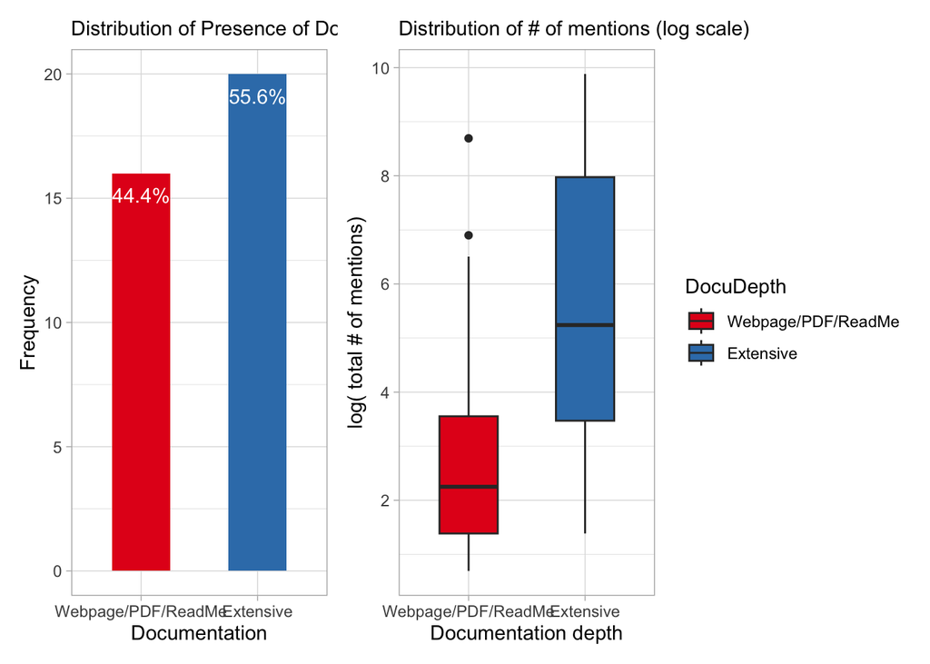

```r
## Marginal dist
p_doc1 <- regdat %>%
  ggplot(aes(x = DocuDepth, fill = fct_infreq(DocuDepth))) +
  geom_bar(position = "dodge", width = .5, show.legend = F) +
  geom_text(stat = 'count',
            aes(label = paste0(after_stat(round(100*count/sum(count),1)), "%")),
            position = position_dodge(width = .9), vjust = 2, col = "white") +
  labs(x = "Documentation", y = "Frequency", subtitle = "Distribution of Presence of Documentation depth") +
  scale_y_continuous(n.breaks = 7) +
  scale_fill_brewer(palette = "Set1", direction = -1) +
  theme_light()

p_doc2 <- regdat %>%
  ggplot(aes(x = DocuDepth, y = log(totalMentions), fill = DocuDepth)) +
  geom_boxplot(width = 0.5, show.legend = T) +
  scale_y_continuous(n.breaks = 6) +
  scale_fill_brewer(palette = "Set1", direction = 1) +
  labs(x = "Documentation depth", y = "log( total # of mentions)",
       subtitle = "Distribution of # of mentions (log scale)") +
  theme_light()

p_doc1 + p_doc2
```

```r
lm(log(totalMentions) ~ DocuDepth, data = regdat) %>% broom::tidy() %>%
  mutate(across(.cols = where(is.numeric), .fns = ~round(.x, digits = 5))) %>%
  DT::datatable()
```

|  | term | estimate | std.error | statistic | p.value |
| --- | --- | --- | --- | --- | --- |
| 1 | (Intercept) | 3.05423 | 0.64749 | 4.71701 | 4e-05 |
| 2 | DocuDepthExtensive | 2.39387 | 0.8687 | 2.75569 | 0.00934 |

```r
regdat %>% mutate(extensiveContact = if_else(extensiveContact == "None", extensiveContact, "Yes")) %>%
lm(log(totalMentions) ~ extensiveContact + DocuDepth + toolAge, data = .) %>% broom::tidy() %>%
  mutate(across(.cols = where(is.numeric), .fns = ~round(.x, digits = 5))) %>%
  DT::datatable()
```

|  | term | estimate | std.error | statistic | p.value |
| --- | --- | --- | --- | --- | --- |
| 1 | (Intercept) | 0.72769 | 0.59523 | 1.22254 | 0.23043 |
| 2 | extensiveContactYes | 1.84338 | 0.73021 | 2.52444 | 0.01675 |
| 3 | DocuDepthExtensive | 0.94263 | 0.62838 | 1.50009 | 0.14339 |
| 4 | toolAge | 0.24568 | 0.06885 | 3.56843 | 0.00116 |

```r
lm(log(totalMentions) ~ DocuDepth + socialMedia + extensiveContact + toolAge, data = regdat) %>% broom::tidy() %>%
  mutate(across(.cols = where(is.numeric), .fns = ~round(.x, digits = 5))) %>%
  DT::datatable()
```

|  | term | estimate | std.error | statistic | p.value |
| --- | --- | --- | --- | --- | --- |
| 1 | (Intercept) | 0.77723 | 0.60482 | 1.28507 | 0.20829 |
| 2 | DocuDepthExtensive | 0.89999 | 0.63693 | 1.41302 | 0.16761 |
| 3 | socialMediaYes | 0.53015 | 0.78501 | 0.67535 | 0.50446 |
| 4 | extensiveContactYes | 1.66145 | 0.78422 | 2.11861 | 0.04224 |
| 5 | toolAge | 0.23276 | 0.07203 | 3.23137 | 0.00292 |

```r
#names(regdat)
lm(log(Usage) ~ toolAge +simple_health_metrics*socialMedia, data = filter(regdat, toolAge >=3) ) %>% broom::tidy() %>%
  mutate(across(.cols = where(is.numeric), .fns = ~round(.x, digits = 5))) %>%
  DT::datatable()
```

|  | term | estimate | std.error | statistic | p.value |
| --- | --- | --- | --- | --- | --- |
| 1 | (Intercept) | -0.43418 | 0.93998 | -0.4619 | 0.6489 |
| 2 | toolAge | 0.36849 | 0.08933 | 4.12484 | 0.00048 |
| 3 | simple_health_metricsYes | 2.07639 | 1.10731 | 1.87517 | 0.07474 |
| 4 | socialMediaYes | 1.93304 | 1.29833 | 1.48886 | 0.15139 |
| 5 | simple_health_metricsYes:socialMediaYes | -1.93348 | 1.82782 | -1.0578 | 0.30216 |

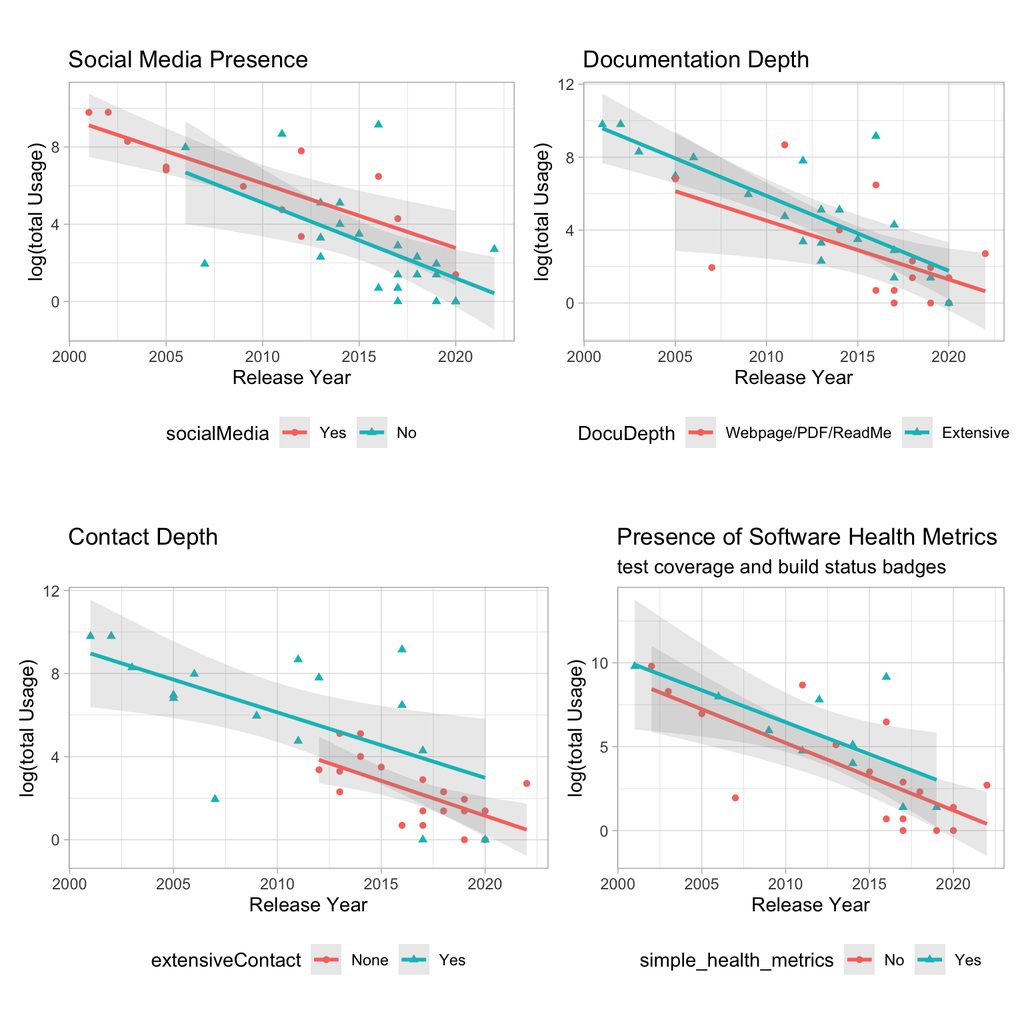

```r
# Social Media

regdat %<>% mutate(
  socialMedia = factor(socialMedia, levels = c("Yes", "No")),

)
d1 <- regdat %>%
  ggplot(aes(x = releaseYear, y = log(Usage), col = socialMedia)) +
  geom_point(aes(shape = socialMedia)) +
  geom_smooth(method = "lm", se = T, alpha = 0.2) +
  labs(x = "Release Year", y = "log(total Usage)", title = "Social Media Presence") +
  theme_light() +coord_equal() + theme(legend.position = "bottom")

## DocuDepth
d2 <- regdat %>%
  ggplot(aes(x = releaseYear, y = log(Usage), col = DocuDepth)) +
  geom_point(aes(shape = DocuDepth)) +
  geom_smooth(method = "lm", se = T, alpha = 0.2) +
  labs(x = "Release Year", y = "log(total Usage)", title = "Documentation Depth") +
  theme_light() +coord_equal() + theme(legend.position = "bottom")

# extensiveContact
d3 <- regdat %>%
  ggplot(aes(x = releaseYear, y = log(Usage), col = extensiveContact)) +
  geom_point(aes(shape = extensiveContact)) +
  geom_smooth(method = "lm", se = T, alpha = 0.2) +
  labs(x = "Release Year", y = "log(total Usage)", title = "Contact Depth") +
  theme_light() +coord_equal() + theme(legend.position = "bottom")

# CiteHow
d4 <- regdat %>%
  ggplot(aes(x = releaseYear, y = log(Usage), col = citeHow)) +
  geom_point(aes(shape = citeHow)) +
  geom_smooth(method = "lm", se = T, alpha = 0.2) +
  labs(x = "Release Year", y = "log(total Usage)", subtitle = "Information for citing") +
  theme_light() +coord_equal() + theme(legend.position = "bottom")

# health metrics
d5 <- regdat %>% drop_na(simple_health_metrics) %>%
  ggplot(aes(x = releaseYear, y = log(Usage), col = simple_health_metrics)) +
  geom_point(aes(shape = simple_health_metrics)) +
  geom_smooth(method = "lm", se = T, alpha = 0.2) +
  labs(x = "Release Year", y = "log(total Usage)", title = "Presence of Software Health Metrics", subtitle = ("test coverage and build status badges")) +
  theme_light() +coord_equal() + theme(legend.position = "bottom")

(d1 + d2) / (d3 + d5)
```

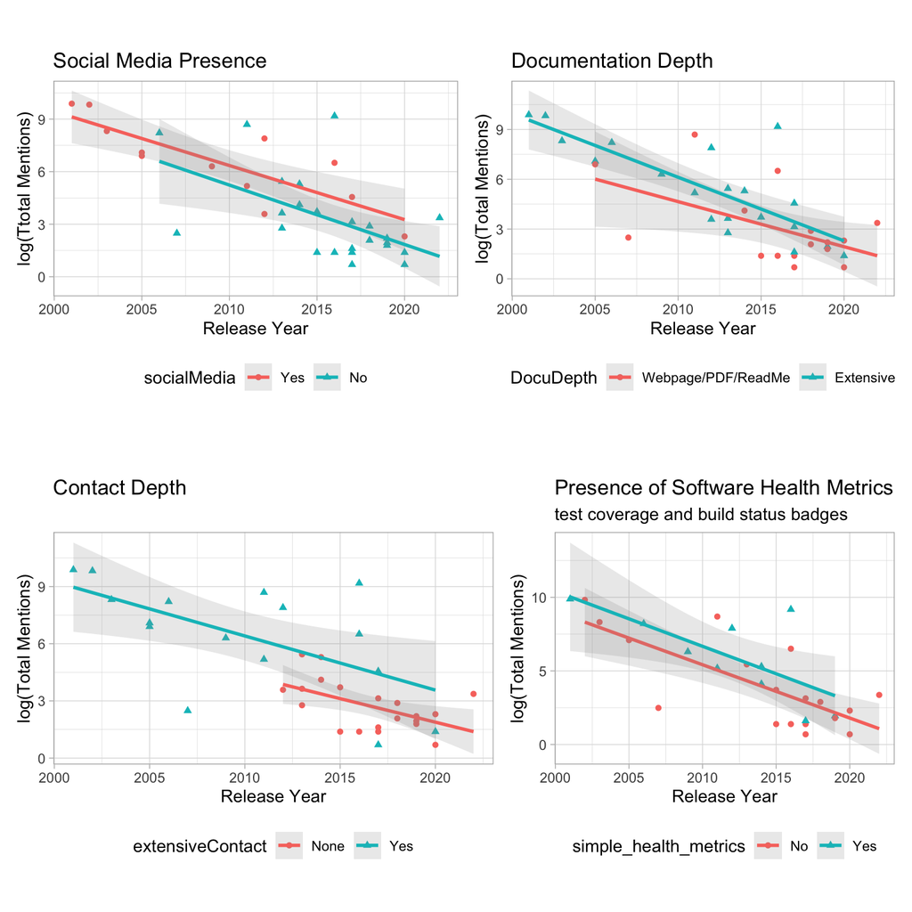

```r
# Social Media
d11 <- regdat %>%
  ggplot(aes(x = releaseYear, y = log(totalMentions), col = socialMedia)) +
  geom_point(aes(shape = socialMedia)) +
  geom_smooth(method = "lm", se = T, alpha = 0.2) +
  labs(x = "Release Year", y = "log(Ttotal Mentions)", title = "Social Media Presence") +
  theme_light() +coord_equal() + theme(legend.position = "bottom")

## DocuDepth
d22 <- regdat %>%
  ggplot(aes(x = releaseYear, y = log(totalMentions), col = DocuDepth)) +
  geom_point(aes(shape = DocuDepth)) +
  geom_smooth(method = "lm", se = T, alpha = 0.2) +
  labs(x = "Release Year", y = "log(Total Mentions)", title = "Documentation Depth") +
  theme_light() +coord_equal() + theme(legend.position = "bottom")

# extensiveContact
d33 <- regdat %>%
  ggplot(aes(x = releaseYear, y = log(totalMentions), col = extensiveContact)) +
  geom_point(aes(shape = extensiveContact)) +
  geom_smooth(method = "lm", se = T, alpha = 0.2) +
  labs(x = "Release Year", y = "log(Total Mentions)", title =  "Contact Depth") +
  theme_light() +coord_equal() + theme(legend.position = "bottom")

# CiteHow
d44 <- regdat %>%
  ggplot(aes(x = releaseYear, y = log(totalMentions), col = citeHow)) +
  geom_point(aes(shape = citeHow)) +
  geom_smooth(method = "lm", se = T, alpha = 0.2) +
  labs(x = "Release Year", y = "log(Total Mentions)", subtitle = "Information on how to cite") +
  theme_light() +coord_equal() + theme(legend.position = "bottom")

d55<- regdat %>% drop_na(simple_health_metrics) %>%
  ggplot(aes(x = releaseYear, y = log(totalMentions), col = simple_health_metrics)) +
  geom_point(aes(shape = simple_health_metrics)) +
  geom_smooth(method = "lm", se = T, alpha = 0.2) +
  labs(x = "Release Year", y = "log(Total Mentions)", title = "Presence of Software Health Metrics", subtitle = ("test coverage and build status badges")) +
  theme_light() +coord_equal() + theme(legend.position = "bottom")

(d11 + d22) / (d33 + d55)
```

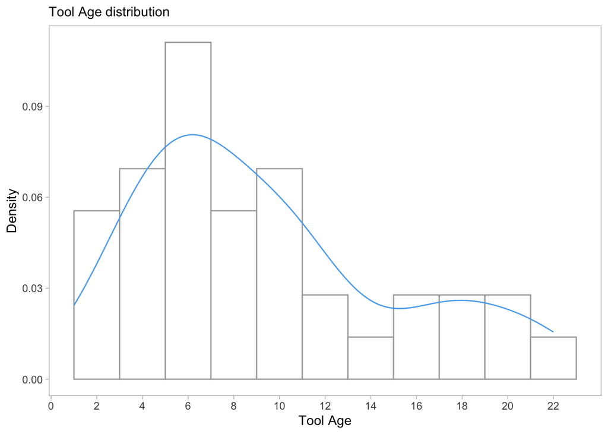

```r
regdat  %>%
  ggplot(aes(x = toolAge)) +
  geom_histogram(aes(y = after_stat(density)), fill = "white", col = "darkgray", binwidth = 2) +
  geom_density(col = "steelblue2") +
  scale_x_continuous(breaks = seq(0, 22, by = 2)) +
  labs(x = "Tool Age", y = "Density", subtitle = "Tool Age distribution") +
  theme_light() +
  theme(
    panel.grid = element_blank()
  )
```

## Freq table for type of Social Media

```r
regdat %>% count(Twitter.bi, Youtube.bi, OtherMedia.bi)
```

```
## # A tibble: 5 × 4
##   Twitter.bi Youtube.bi OtherMedia.bi     n
##   <chr>      <chr>      <chr>         <int>
## 1 No         No         No               24
## 2 No         Yes        No                1
## 3 Yes        No         No                9
## 4 Yes        No         Yes               1
## 5 Yes        Yes        No                1
```